# Assignment 10: Text Analysis in R

Brian Roepke

Nov 15, 2020

```r
# Text mining libs
library(SnowballC)
library(tidytext)
library(spacyr)
library(tm)
library(wordcloud2)
library(ggraph)
library(textstem)

# plotting and pipes - tidyverse
library(ggplot2)
library(dplyr, warn.conflicts = FALSE)
library(tidyverse)

# date/time libaray
library(lubridate, warn.conflicts = FALSE)
```

```r
# Read in the Data from a CSV file.
df <- read.csv('news_headlines.csv', colClasses=c("headline"="character"))
```

```r
# Perform column cleanup as needed
df$publish_date <- as.Date(df$publish_date, "%d/%m/%y")
```

# EDA

Perform Exploratory Data Analysis to better understand what’s in this set.

## Summary Statistics

```r
summary(df)
```

```
##   publish_date          headline
##  Min.   :2009-01-01   Length:752157
##  1st Qu.:2011-06-09   Class :character
##  Median :2013-08-08   Mode  :character
##  Mean   :2013-10-18
##  3rd Qu.:2015-12-05
##  Max.   :2019-12-12
##  NA's   :455200
```

- **publish_date**: Dates range from 1/1/2009 to 12/12/2019; however, there are 455,200 missing dates.
- **headline**: There are a total of 752,157 headlines (records) in this dataset.

```r
head(df)
```

|  | publish_date | headline |
| --- | --- | --- |
| 1 | 2009-01-01 | 2008 deadliest year for us forces in afghanistan |
| 2 | 2009-01-01 | 2008 dubbed wet year for hunter |
| 3 | 2009-01-01 | 2 israelis injured in danish mall shooting |
| 4 | 2009-01-01 | 8500 qld homes without power after storms |
| 5 | 2009-01-01 | about 60 killed in bankgok fire |
| 6 | 2009-01-01 | act govt bodies forced to comply with human rights |

```r
tail(df)
```

|  | publish_date | headline |
| --- | --- | --- |
| 752152 |  | victorian bushfire emergency mallacoota gippsland corryong |
| 752153 |  | vision of flames approaching corryong in victoria |
| 752154 |  | wa police and government backflip on drug amnesty bins |
| 752155 |  | we have fears for their safety: victorian premier |
| 752156 |  | when do the 20s start |
| 752157 |  | yarraville shooting woman dead man critically injured |

### Remove Duplicates

```r
df[duplicated(df$headline), ] %>%
  head()
```

|  | publish_date | headline |
| --- | --- | --- |
| 255 | 2009-02-01 | fireworks suspected in deadly thai nightclub blaze |
| 1472 | 2009-08-01 | family celebrates mcdonalds test debut |
| 2293 | 2009-12-01 | israel pushes deeper into gaza |
| 4094 |  | pilot killed in light plane crash |
| 4605 |  | southern stars cup squad named |
| 4727 |  | east gippsland lightning fires under control |

```r
df2 <- df[!duplicated(df$headline), ]
length(df$headline) - length(df2$headline)
```

```
## [1] 25022
```

**note:** `25,022` duplicates entries were removed.

### Add New Columns to Support Analysis

There are a few things that will help with the anaysis—a length value for the headline and breaking up the dates into individual columns as well as adding a daw of week variable.

```r
df3 <- df2 %>%
  mutate(headline_len = str_count(df2$headline)) %>%
  mutate(year = lubridate::year(df2$publish_date)) %>%
  mutate(month = lubridate::month(df2$publish_date)) %>%
  mutate(day = lubridate::day(df2$publish_date)) %>%
  mutate(dow = weekdays(df2$publish_date))
```

Reorder the columns to a more logical sequence

```r
df3 <- select(df3, publish_date, year, month, day, dow, headline, headline_len)
head(df3)
```

|  | publish_date | year | month | day | dow | headline | headline_len |
| --- | --- | --- | --- | --- | --- | --- | --- |
| 1 | 2009-01-01 | 2009 | 1 | 1 | Thursday | 2008 deadliest year for us forces in afghanistan | 48 |
| 2 | 2009-01-01 | 2009 | 1 | 1 | Thursday | 2008 dubbed wet year for hunter | 31 |
| 3 | 2009-01-01 | 2009 | 1 | 1 | Thursday | 2 israelis injured in danish mall shooting | 42 |
| 4 | 2009-01-01 | 2009 | 1 | 1 | Thursday | 8500 qld homes without power after storms | 41 |
| 5 | 2009-01-01 | 2009 | 1 | 1 | Thursday | about 60 killed in bankgok fire | 31 |
| 6 | 2009-01-01 | 2009 | 1 | 1 | Thursday | act govt bodies forced to comply with human rights | 50 |

### Summary Statistics for Headline Length

```r
summary(df3$headline_len)
```

```
##    Min. 1st Qu.  Median    Mean 3rd Qu.    Max.
##     4.0    34.0    43.0    42.3    50.0    70.0
```

The min length is `4.0`, max of `70` and a mean of `42.3`.

### Plot a Histogram of the Headline Length Statistics

First determine the best bin size using Sturges’ formula. https://www.statisticshowto.com/choose-bin-sizes-statistics/

```r
hl_bins <- round(log2(length(df3$headline)) + 1)
hl_bins
```

```
## [1] 20
```

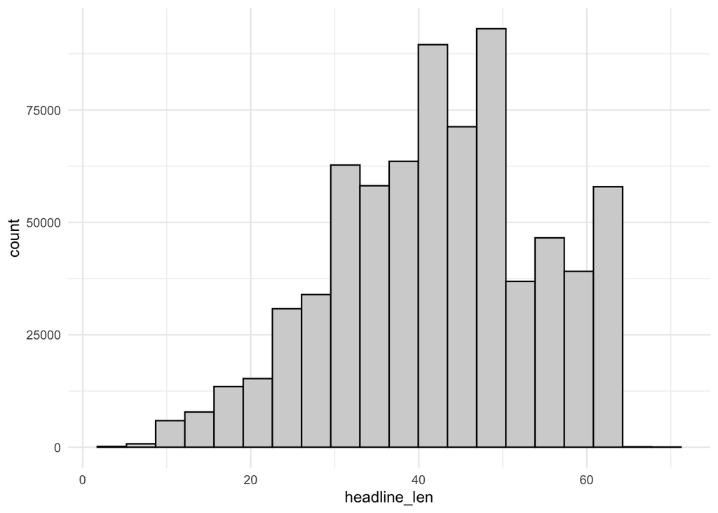

```r
df3 %>%
  ggplot(aes(x = headline_len)) +
  geom_histogram(color = "black", fill = "lightgray", bins = hl_bins) +
  theme_minimal()
```

## Date Analysis

```r
df_dates <- drop_na(df3)

df_dates %>%
  select(publish_date, headline) %>%
  summary()
```

```
##   publish_date          headline
##  Min.   :2009-01-01   Length:287039
##  1st Qu.:2011-06-07   Class :character
##  Median :2013-09-01   Mode  :character
##  Mean   :2013-10-23
##  3rd Qu.:2015-12-10
##  Max.   :2019-12-12
```

After dropping `NULL` dates, we’re left with `287,039` headlines

### Ploting Posts per Day over time.

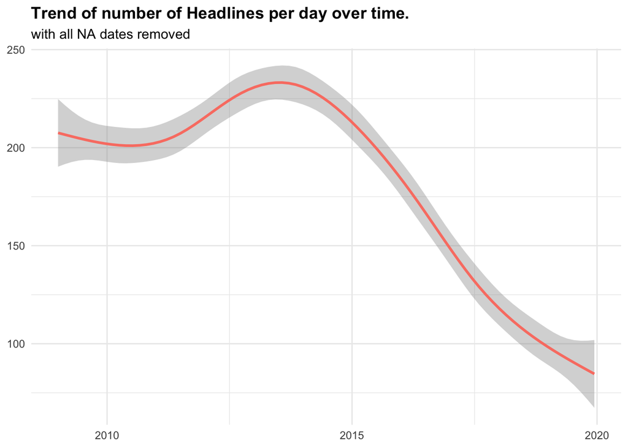

```r
df_ts <- df_dates %>%
  group_by(publish_date) %>%
  summarise(headlines = n(), .groups = "keep")

df_ts %>%
  ggplot(aes(x = publish_date, y= headlines)) +
  geom_smooth(method = 'gam', formula = y ~ s(x, bs = "cs"), color = "salmon") +
  theme_minimal() +
  theme(
  plot.title = element_text(face = "bold")) +
  labs(
  x = NULL, y = NULL,
  title = "Trend of number of Headlines per day over time.",
  subtitle = "with all NA dates removed"
  )
```

Headlines in the dataset (with Dates) are relatively consistent between `2009`-`2015` with approximately `200`-`230` headlines per day. Still, then it tapers off through `2020.` The headlines without dates may represent headlines for these later years.

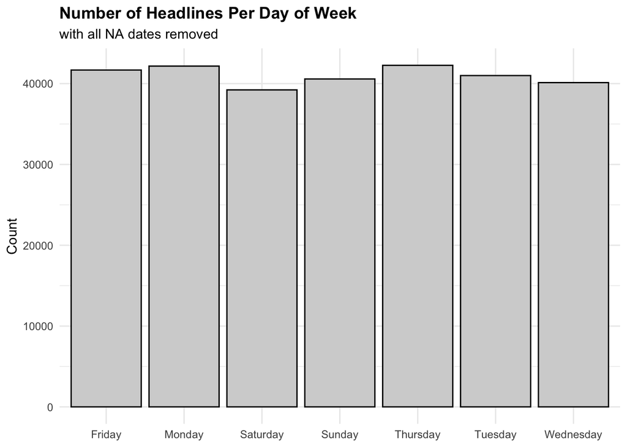

```r
df_dates %>%
  ggplot(aes(x = dow)) +
  geom_bar(color = "black", fill = "lightgray") +
  theme_minimal() +
  theme(
  plot.title = element_text(face = "bold")) +
  labs(
  x = NULL, y = "Count",
  title = "Number of Headlines Per Day of Week",
  subtitle = "with all NA dates removed"
  )
```

Generally speaking, there isn’t much variation in which day of the week the headlines come from; there is a fairly consistent number for each day of the week.

# Text Analysis

Next we’ll perform an text analysis to look at frequencies of words, after the text has been pre-processed.

```r
# build a document corpus
headline_corpus <- Corpus(VectorSource(df3$headline))
headline_corpus
```

```
## <<SimpleCorpus>>
## Metadata:  corpus specific: 1, document level (indexed): 0
## Content:  documents: 727135
```

```r
inspect(headline_corpus[1:4])
```

```
## <<SimpleCorpus>>
## Metadata:  corpus specific: 1, document level (indexed): 0
## Content:  documents: 4
##
## [1] 2008 deadliest year for us forces in afghanistan
## [2] 2008 dubbed wet year for hunter
## [3] 2 israelis injured in danish mall shooting
## [4] 8500 qld homes without power after storms
```

## Preprocessing

Using the `tm` package, perform transformations on the corpus to clean the text. There are generalized text cleaning activities such as normalization and stop word removal.

```r
# standard cleansing
headline_corpus <- tm_map(headline_corpus, tolower)            # normalize case
headline_corpus <- tm_map(headline_corpus, removePunctuation)  # remove punctuation
headline_corpus <- tm_map(headline_corpus, removeNumbers)      # remove numbers
headline_corpus <- tm_map(headline_corpus, stripWhitespace)    # remove white space
headline_corpus <- tm_map(headline_corpus, removeWords, stopwords("english")) # remove stopwords
```

## Stemming

Use the SnowBall stemming algorithm to stem words in the text and inspect a few rows.

```r
# stem words using SnowBall stemmer
headline_corpus <- tm_map(headline_corpus, stemDocument)
# inspect the first 3 documents
inspect(headline_corpus[1:5])
```

```
## <<SimpleCorpus>>
## Metadata:  corpus specific: 1, document level (indexed): 0
## Content:  documents: 5
##
## [1] deadliest year us forc afghanistan dub wet year hunter
## [3] isra injur danish mall shoot       qld home without power storm
## [5] kill bankgok fire
```

## Document-Term Matrix

Create a `Term-Document Matrix` from the cleaned Corpus

```r
# The term document matrix is where each word/term is a row with documents as columns
dtm <- TermDocumentMatrix(headline_corpus)

# inspect
inspect(dtm)
```

```
## <<TermDocumentMatrix (terms: 63390, documents: 727135)>>
## Non-/sparse entries: 3890763/46089196887
## Sparsity           : 100%
## Maximal term length: 45
## Weighting          : term frequency (tf)
## Sample             :
##             Docs
## Terms        342210 374301 378095 378828 379460 380229 383941 385031 633244
##   australia       0      0      0      0      0      0      0      0      0
##   australian      0      0      0      0      0      0      0      0      0
##   call            0      0      0      0      0      0      0      0      0
##   charg           0      0      0      0      0      0      0      0      0
##   fire            0      0      0      2      0      0      0      0      0
##   man             0      0      0      0      0      0      0      0      0
##   new             0      0      1      0      0      0      1      0      0
##   plan            0      0      0      0      0      0      0      0      0
##   polic           0      0      0      0      0      0      0      0      0
##   say             0      0      0      1      0      0      1      0      0
##             Docs
## Terms        673505
##   australia       0
##   australian      1
##   call            0
##   charg           0
##   fire            0
##   man             0
##   new             0
##   plan            0
##   polic           0
##   say             0
```

**Note:** Term-document matrices tend to get very big already for normal sized data sets. Therefore function `removeSparseTerms()` can be used to remove sparse terms (i.e., terms occurring only in very few documents). Normally, this reduces the matrix dramatically without losing significant relations inherent to the matrix. The sparse argument to `removeSparseTerms()`, is the threshold of relative document frequency for a term, above which the term will be removed. It is a value between 0 and 1. Closer to 0 means nearly all values will be retained while closer to 1 means nearly none of the documents will be retained.

Since this is a very large and sparse corpus, we will remove all but the top `0.001` words

```r
dtm3 = removeSparseTerms(dtm, .999)
```

## Perform Analysis

### Frequent Terms

- Use `freqwords()`: find frequent terms in a document-term or term-document matrix.
- Find terms that occur at least 5 times and show top 50

```r
findFreqTerms(dtm3, 5) %>%
  head(50)
```

```
##  [1] "afghanistan" "forc"        "year"        "hunter"      "injur"
##  [6] "shoot"       "home"        "power"       "qld"         "storm"
## [11] "without"     "fire"        "kill"        "act"         "bodi"
## [16] "govt"        "human"       "right"       "growth"      "predict"
## [21] "price"       "properti"    "cost"        "cut"         "alic"
## [26] "arrest"      "celebr"      "new"         "polic"       "anger"
## [31] "fall"        "festiv"      "grow"        "test"        "reveal"
## [36] "swan"        "shot"        "assault"     "sydney"      "aid"
## [41] "australia"   "welcom"      "bad"         "road"        "start"
## [46] "vic"         "defeat"      "honour"      "bendigo"     "eas"
```

### Word associations

```r
# word associations
findAssocs(dtm3, c('health', 'assault', 'donald'), c(0.10, 0.10, 0.10))
```

```
## $health
## mental
##   0.41
##
## $assault
## sexual  charg
##   0.28   0.11
##
## $donald
## trump
##  0.65
```

Even with the lower correlation value for matching terms, just a few results are returned. *Mental* with a `0.41` correlation to *Health*, *Assault* has two words, *Sexual* and *Charg*, which correlate `0.28` and `0.11` respectively. In contrast, *Trump* correlates strongly to *Donald* at `0.65`.

```r
termCount <- rowSums(as.matrix(dtm3))  # sums rows
termCount <- subset(termCount, termCount >=20)

df <- data.frame(term = names(termCount), freq = termCount)
```

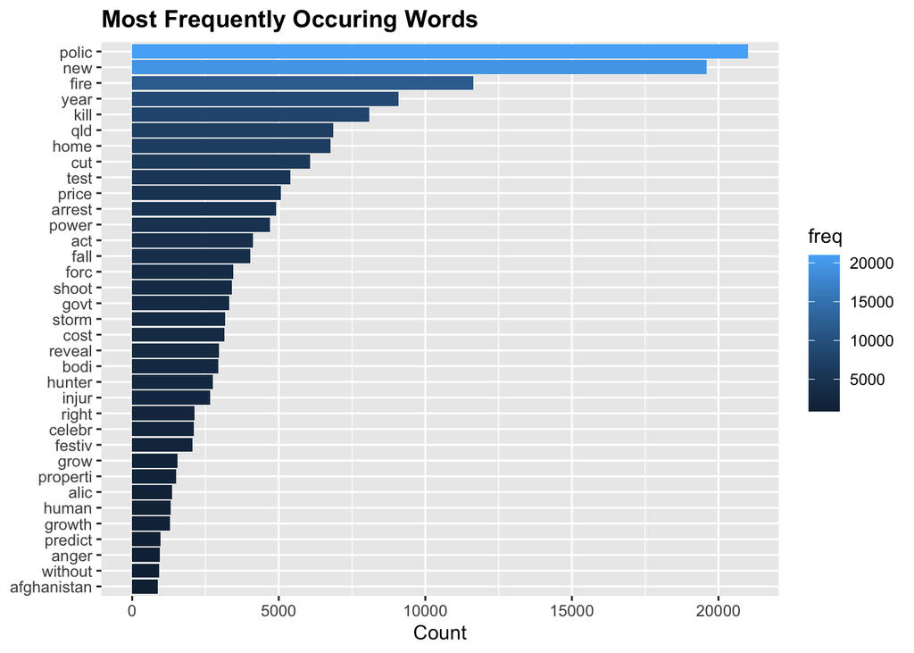

```r
df %>%
  head(35) %>%
  ggplot( aes(x = reorder(term, freq), y = freq, fill= freq)) +
    geom_bar(stat = "identity") +
    scale_colour_gradientn(colors = terrain.colors(10)) +
    coord_flip() +
    theme(
    plot.title = element_text(face = "bold")) +
    labs(
    x = NULL, y = "Count",
    title = "Most Frequently Occuring Words"
    )
```

```r
df %>%
  head(200) %>%
  wordcloud2(color = "random-dark", backgroundColor = "white")
```

[interactive chart not shown]

## Perform a Similar Analysis Using Tidytext

An advantage of tidytext format is that once the text has been tidy-ed, regular R functions can be used to analyze it instead of the specialized functions necessary to analyze a Corpus object. We can perform some of the same analyis as above the tidy way as follows.

### tidying data

```r
# convert dataframe to tibble
tidy_df <- as_tibble(df3$headline)

# the text is itself a dataframe? modify the text column to pull out the text value
tidy_df <- tidy_df %>%
  mutate(text =  tidy_df$value)  %>%
  select(-value)
tidy_df
```

| text |
| --- |
| 2008 deadliest year for us forces in afghanistan |
| 2008 dubbed wet year for hunter |
| 2 israelis injured in danish mall shooting |
| 8500 qld homes without power after storms |
| about 60 killed in bankgok fire |
| act govt bodies forced to comply with human rights |
| act property prices down growth predicted |
| act self govt seen as cost cutting exercise |
| alice police arrest 83 in new year celebrations |
| anger grows at falls festival breath tests |

[output cut: 9990 more lines]

## break text into tokens using tidytext

The unnest_tokens() function, part of tidytext, performs some automatic text cleaning

The unnest_tokens() function takes 2 arguments: the name of the column where the unique word will be stored the column name from the data frame containing the text Converts each word in text to lowercase, Punctuation is removed: eg: periods, commas etc

```r
tidy_df <- tidy_df %>%
    unnest_tokens(word, text) %>%
    count(word) %>%
    arrange(desc(n))

tidy_df
```

| word | n |
| --- | --- |
| to | 132405 |
| in | 95031 |
| for | 81904 |
| of | 61627 |
| on | 49266 |
| the | 48455 |
| over | 30573 |
| at | 24468 |
| a | 22441 |
| with | 21898 |

[output cut: 9990 more lines]

### text cleaning

remove stop words & then perform stemming

```r
tidy_df = tidy_df  %>%
  anti_join(stop_words) # stop words
tidy_df = tidy_df %>%
  mutate(stem = wordStem(word))

tidy_df
```

| word | n | stem |
| --- | --- | --- |
| police | 20893 | polic |
| australia | 11345 | australia |
| court | 10668 | court |
| australian | 10019 | australian |
| nsw | 9715 | nsw |
| fire | 9448 | fire |
| council | 8326 | council |
| wa | 8152 | wa |
| sydney | 8139 | sydnei |
| government | 8038 | govern |

[output cut: 9990 more lines]

### Plot top 30 terms having a frequency of 20 or higher

```r
tidy_df = tidy_df%>%
    filter(n >= 20)  %>%
    mutate(word = reorder(word, n)) %>%
    head(30)
```

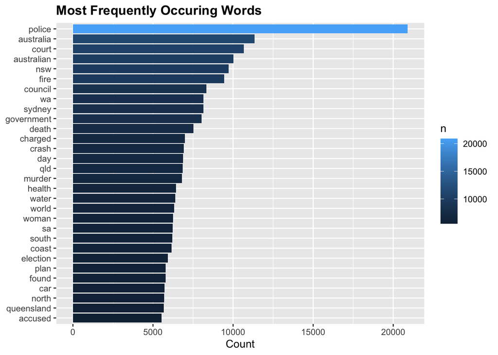

```r
ggplot(tidy_df, aes(x = reorder(word, n), y = n, fill=n)) +
    geom_bar(stat = "identity") +
    scale_colour_gradientn(colors = terrain.colors(10)) +
    coord_flip() +
    theme(
    plot.title = element_text(face = "bold")) +
    labs(
    x = NULL, y = "Count",
    title = "Most Frequently Occuring Words"
    )
```

## Top bi-grams

A bigram is an n-gram for n=2. Here we show the top (15) 2 word phrases.

```r
df2 = df3 %>%
  # get bi-grams
  unnest_tokens(bigram, headline, token = "ngrams", n = 2) %>%
  # separate bi-grams into different columns
  separate(bigram, c("word1", "word2"), sep = " ")

bigrams = df2  %>%
  filter(!word1 %in% stop_words$word) %>% # filter out stop words
  filter(!word2 %in% stop_words$word) %>%
  count(word1, word2, sort = TRUE) %>%
  head(15)

bigrams
```

|  | word1 | word2 | n |
| --- | --- | --- | --- |
| 1 | country | hour | 2778 |
| 2 | gold | coast | 2305 |
| 3 | world | cup | 2275 |
| 4 | donald | trump | 1851 |
| 5 | mental | health | 1430 |
| 6 | climate | change | 1326 |
| 7 | royal | commission | 1250 |
| 8 | asylum | seekers | 1123 |
| 9 | north | korea | 1114 |
| 10 | pleads | guilty | 1051 |

[output cut: 5 more lines]

### Visualizing a network of bigrams with ggraph

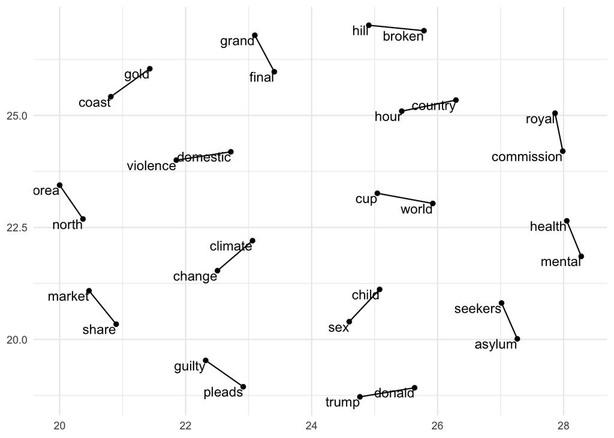

```r
set.seed(2017)

ggraph(bigrams, layout = "fr") +
  geom_edge_link() +
  geom_node_point() +
  geom_node_text(aes(label = name), vjust = 1, hjust = 1) +
  xlab(NULL) + ylab(NULL) + theme_minimal()
```

## Lemmatization

One thing not covered so far is the Lemmatization, or the process of breaking a word down into it’s root form or “Lemma”. Overally the text of these headlines probably doesn’t warrant Lemmatization, but it is interesting to try.

Here is a simple example of this on three forms of the word Run.

```r
vector <- c("run", "ran", "running")
lemmatize_words(vector)
```

```
## [1] "run" "run" "run"
```

```r
lemma_corpus <- Corpus(VectorSource(df3$headline))
lemma_corpus
```

```
## <<SimpleCorpus>>
## Metadata:  corpus specific: 1, document level (indexed): 0
## Content:  documents: 727135
```

```r
# standard cleansing
lemma_corpus <- tm_map(lemma_corpus, tolower)            # normalize case
lemma_corpus <- tm_map(lemma_corpus, removePunctuation)  # remove punctuation
lemma_corpus <- tm_map(lemma_corpus, removeNumbers)      # remove numbers
lemma_corpus <- tm_map(lemma_corpus, stripWhitespace)    # remove white space
lemma_corpus <- tm_map(lemma_corpus, removeWords, stopwords("english")) # remove stopwords
inspect(lemma_corpus[1:5])
```

```
## <<SimpleCorpus>>
## Metadata:  corpus specific: 1, document level (indexed): 0
## Content:  documents: 5
##
## [1]  deadliest year  us forces  afghanistan
## [2]  dubbed wet year  hunter
## [3]  israelis injured  danish mall shooting
## [4]  qld homes without power  storms
## [5]  killed  bankgok fire
```

```r
lemma_corpus <- tm_map(lemma_corpus, lemmatize_strings)
inspect(lemma_corpus[1:5])
```

```
## <<SimpleCorpus>>
## Metadata:  corpus specific: 1, document level (indexed): 0
## Content:  documents: 5
##
## [1] deadly year us force afghanistan dub wet year hunter
## [3] israeli injure danish mall shoot qld home without power storm
## [5] kill bankgok fire
```

### Create the same Document Term Matrix as Above

```r
# The term document matrix is where each word/term is a row with documents as columns
lemma_dtm <- TermDocumentMatrix(lemma_corpus)

# inspect
inspect(lemma_dtm)
```

```
## <<TermDocumentMatrix (terms: 73895, documents: 727135)>>
## Non-/sparse entries: 3886796/53727754029
## Sparsity           : 100%
## Maximal term length: 45
## Weighting          : term frequency (tf)
## Sample             :
##             Docs
## Terms        342210 359232 374301 378095 378828 379460 380229 383941 633244
##   australia       0      0      0      0      0      0      0      0      0
##   australian      0      0      0      0      0      0      0      0      0
##   call            0      0      0      0      0      0      0      0      0
##   charge          0      0      0      0      0      0      0      0      0
##   fire            0      0      0      0      2      0      0      0      0
##   man             0      0      0      0      0      0      0      0      0
##   new             0      0      0      1      0      0      0      1      0
##   plan            0      0      0      0      0      0      0      0      0
##   police          0      0      0      0      0      0      0      0      0
##   say             0      0      0      0      1      0      0      1      0
##             Docs
## Terms        673505
##   australia       0
##   australian      1
##   call            0
##   charge          0
##   fire            0
##   man             0
##   new             0
##   plan            0
##   police          0
##   say             0
```

```r
lemma_dtm = removeSparseTerms(lemma_dtm, .999)
```

## Perform Analysis

### Frequent Terms

- Use freqwords(): find frequent terms in a document-term or term-document matrix.
- Find terms that occur at least 5 times and show top 50

```r
findFreqTerms(lemma_dtm, 5) %>%
  head(50)
```

```
##  [1] "afghanistan" "deadly"      "force"       "year"        "hunter"
##  [6] "injure"      "shoot"       "home"        "power"       "qld"
## [11] "storm"       "without"     "fire"        "kill"        "act"
## [16] "body"        "govt"        "human"       "right"       "growth"
## [21] "predict"     "price"       "property"    "cost"        "cut"
## [26] "see"         "alice"       "arrest"      "new"         "police"
## [31] "anger"       "fall"        "festival"    "grow"        "test"
## [36] "reveal"      "swan"        "assault"     "sydney"      "aid"
## [41] "australia"   "welcome"     "bad"         "road"        "start"
## [46] "vic"         "defeat"      "honour"      "bendigo"     "ease"
```

```r
termCount2 <- rowSums(as.matrix(lemma_dtm))  # sums rows
termCount2 <- subset(termCount, termCount2 >=20)

df <- data.frame(term = names(termCount2), freq = termCount2)
```

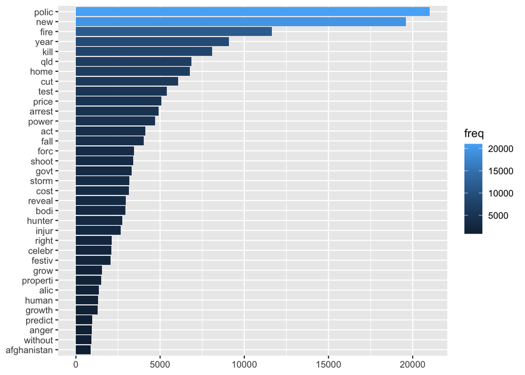

```r
df %>%
  head(35) %>%
  ggplot( aes(x = reorder(term, freq), y = freq, fill= freq)) +
    geom_bar(stat = "identity") +
    scale_colour_gradientn(colors = terrain.colors(10)) +
    xlab(NULL) + ylab(NULL) + coord_flip()
```